# Lesson4_problemset

```r
setwd("~/Udacity/dataAnalysisR/EDA_R_Udacity/lesson4")
```

### Load Library and Data Sets

```r
library(ggplot2)
library(gridExtra)
library(dplyr)
library('alr3')
library(dplyr)
getwd()
```

```
## [1] "C:/Users/Andrew/Documents/Udacity/dataAnalysisR/EDA_R_Udacity/lesson4"
```

```r
list.files()
```

```
##  [1] "correlation_images.jpeg" "hpi-data.xlsx"
##  [3] "hpi.csv"                 "L4.RData"
##  [5] "lesson4_mynotes.html"    "lesson4_mynotes.Rmd"
##  [7] "lesson4_problemset.html" "lesson4_problemset.Rmd"
##  [9] "lesson4_student.html"    "lesson4_student.rmd"
## [11] "workhours_hpi.csv"
```

```r
data(diamonds)
summary(diamonds)
```

```
##      carat               cut        color        clarity
##  Min.   :0.2000   Fair     : 1610   D: 6775   SI1    :13065
##  1st Qu.:0.4000   Good     : 4906   E: 9797   VS2    :12258
##  Median :0.7000   Very Good:12082   F: 9542   SI2    : 9194
##  Mean   :0.7979   Premium  :13791   G:11292   VS1    : 8171
##  3rd Qu.:1.0400   Ideal    :21551   H: 8304   VVS2   : 5066
##  Max.   :5.0100                     I: 5422   VVS1   : 3655
##                                     J: 2808   (Other): 2531
##      depth           table           price             x
##  Min.   :43.00   Min.   :43.00   Min.   :  326   Min.   : 0.000
##  1st Qu.:61.00   1st Qu.:56.00   1st Qu.:  950   1st Qu.: 4.710
##  Median :61.80   Median :57.00   Median : 2401   Median : 5.700
##  Mean   :61.75   Mean   :57.46   Mean   : 3933   Mean   : 5.731
##  3rd Qu.:62.50   3rd Qu.:59.00   3rd Qu.: 5324   3rd Qu.: 6.540
##  Max.   :79.00   Max.   :95.00   Max.   :18823   Max.   :10.740
##
##        y                z
##  Min.   : 0.000   Min.   : 0.000
##  1st Qu.: 4.720   1st Qu.: 2.910
##  Median : 5.710   Median : 3.530
##  Mean   : 5.735   Mean   : 3.539
##  3rd Qu.: 6.540   3rd Qu.: 4.040
##  Max.   :58.900   Max.   :31.800
##
```

```r
names(diamonds)
```

```
##  [1] "carat"   "cut"     "color"   "clarity" "depth"   "table"   "price"
##  [8] "x"       "y"       "z"
```

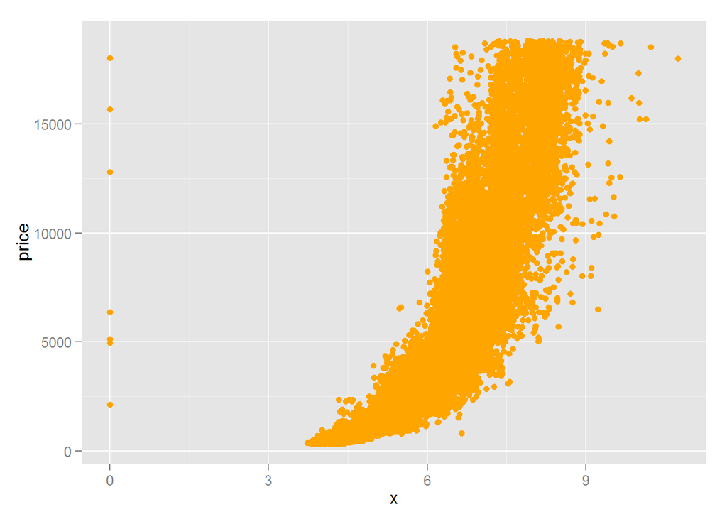

```r
ggplot(aes(x = x , y = price), data = diamonds ) +
  geom_point(color = 'orange')
```

```r
cor.test(diamonds$x, diamonds$price)
```

```
##
##  Pearson's product-moment correlation
##
## data:  diamonds$x and diamonds$price
## t = 440.1594, df = 53938, p-value < 2.2e-16
## alternative hypothesis: true correlation is not equal to 0
## 95 percent confidence interval:
##  0.8825835 0.8862594
## sample estimates:
##       cor
## 0.8844352
```

```r
cor.test(diamonds$y,diamonds$price)
```

```
##
##  Pearson's product-moment correlation
##
## data:  diamonds$y and diamonds$price
## t = 401.1415, df = 53938, p-value < 2.2e-16
## alternative hypothesis: true correlation is not equal to 0
## 95 percent confidence interval:
##  0.8632867 0.8675241
## sample estimates:
##       cor
## 0.8654209
```

```r
cor.test(diamonds$z, diamonds$price)
```

```
##
##  Pearson's product-moment correlation
##
## data:  diamonds$z and diamonds$price
## t = 393.6015, df = 53938, p-value < 2.2e-16
## alternative hypothesis: true correlation is not equal to 0
## 95 percent confidence interval:
##  0.8590541 0.8634131
## sample estimates:
##       cor
## 0.8612494
```

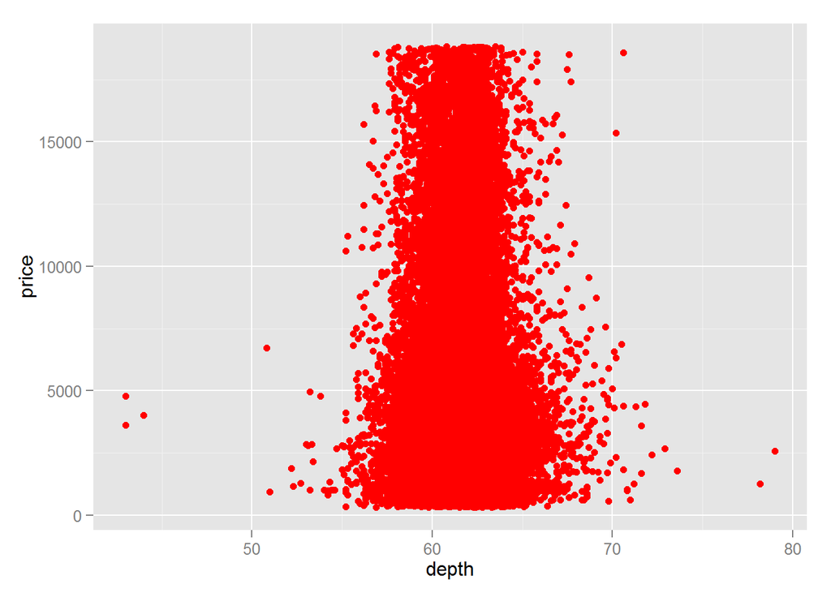

```r
ggplot(aes(x = depth, y = price), data = diamonds) +
  geom_point(color = 'red')
```

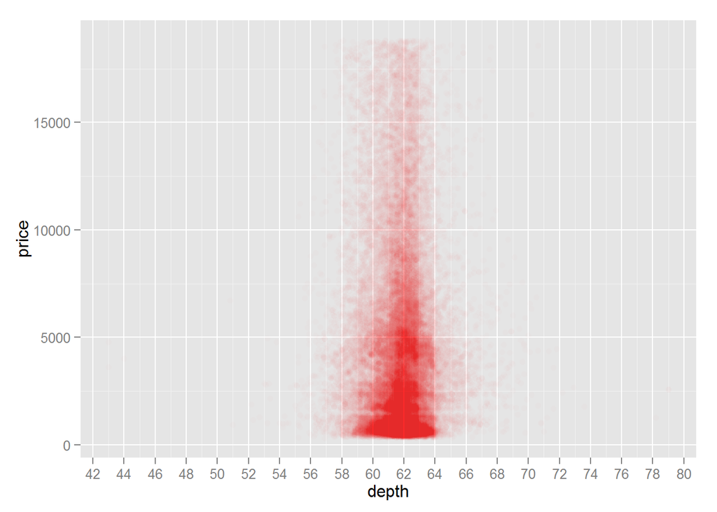

```r
ggplot(aes(x = depth, y = price), data = diamonds) +
  geom_point(alpha = .01, color = 'red') +
  scale_x_continuous(breaks = seq(40,80,2))
```

```r
cor.test(diamonds$depth, diamonds$price)
```

```
##
##  Pearson's product-moment correlation
##
## data:  diamonds$depth and diamonds$price
## t = -2.473, df = 53938, p-value = 0.0134
## alternative hypothesis: true correlation is not equal to 0
## 95 percent confidence interval:
##  -0.019084756 -0.002208537
## sample estimates:
##        cor
## -0.0106474
```

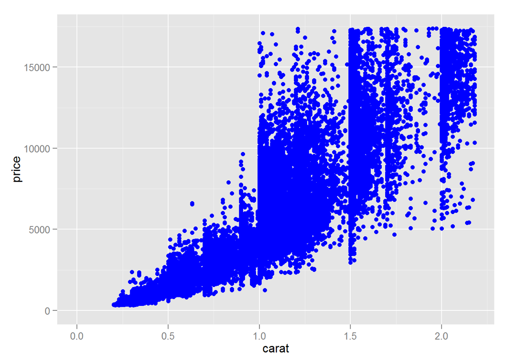

```r
ggplot(aes(x = carat, y = price,), data = diamonds)+
  geom_point(color = 'blue') +
  xlim(0, quantile(diamonds$carat,0.99)) +
  ylim(0, quantile(diamonds$price,0.99))
```

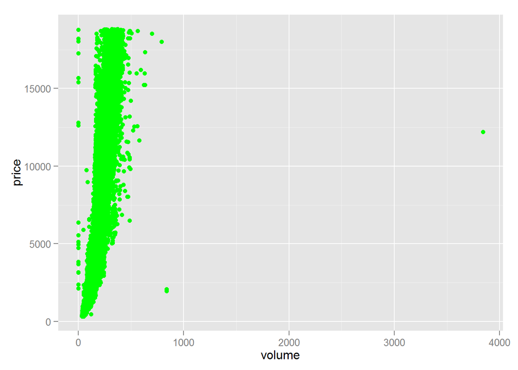

```r
volume = diamonds$x * diamonds$y * diamonds$z
ggplot(aes(x = volume, y = price), data = diamonds) +
  geom_point(color = 'green')
```

```r
diamonds$volume = volume
volume_subset = subset(diamonds, diamonds$volume > 0 & diamonds$volume <=800)
cor.test(volume_subset$volume, volume_subset$price)
```

```
##
##  Pearson's product-moment correlation
##
## data:  volume_subset$volume and volume_subset$price
## t = 559.1912, df = 53915, p-value < 2.2e-16
## alternative hypothesis: true correlation is not equal to 0
## 95 percent confidence interval:
##  0.9222944 0.9247772
## sample estimates:
##       cor
## 0.9235455
```

```
## geom_smooth: method="auto" and size of largest group is >=1000, so using gam with formula: y ~ s(x, bs = "cs"). Use 'method = x' to change the smoothing method.
```

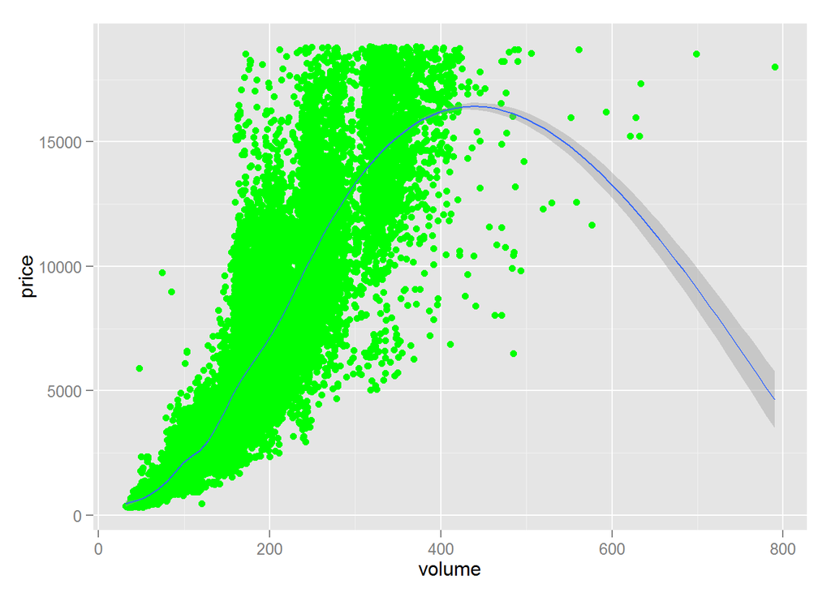

```r
ggplot(aes(x = volume, y = price), data = volume_subset) +
  geom_point(color = 'green') +
  geom_smooth()
```

```r
# Use the function dplyr package
# to create a new data frame containing
# info on diamonds by clarity.

# Name the data frame diamondsByClarity

# The data frame should contain the following
# variables in this order.

#       (1) mean_price
#       (2) median_price
#       (3) min_price
#       (4) max_price
#       (5) n

# where n is the number of diamonds in each
# level of clarity.

diamondsByClarity <- diamonds %>%
  group_by(clarity) %>%
  summarise(mean_price = mean(price),
            median_price = median(as.numeric(price)),#necessary due to bug in version 0.4.1 yesterday (2015-01-14)
            min_price = min(price),
            max_price = max(price),
            n = n()) %>%
  arrange(clarity)

diamondsByClarity
```

```
## Source: local data frame [8 x 6]
##
##   clarity mean_price median_price min_price max_price     n
## 1      I1   3924.169         3344       345     18531   741
## 2     SI2   5063.029         4072       326     18804  9194
## 3     SI1   3996.001         2822       326     18818 13065
## 4     VS2   3924.989         2054       334     18823 12258
## 5     VS1   3839.455         2005       327     18795  8171
## 6    VVS2   3283.737         1311       336     18768  5066
## 7    VVS1   2523.115         1093       336     18777  3655
## 8      IF   2864.839         1080       369     18806  1790
```

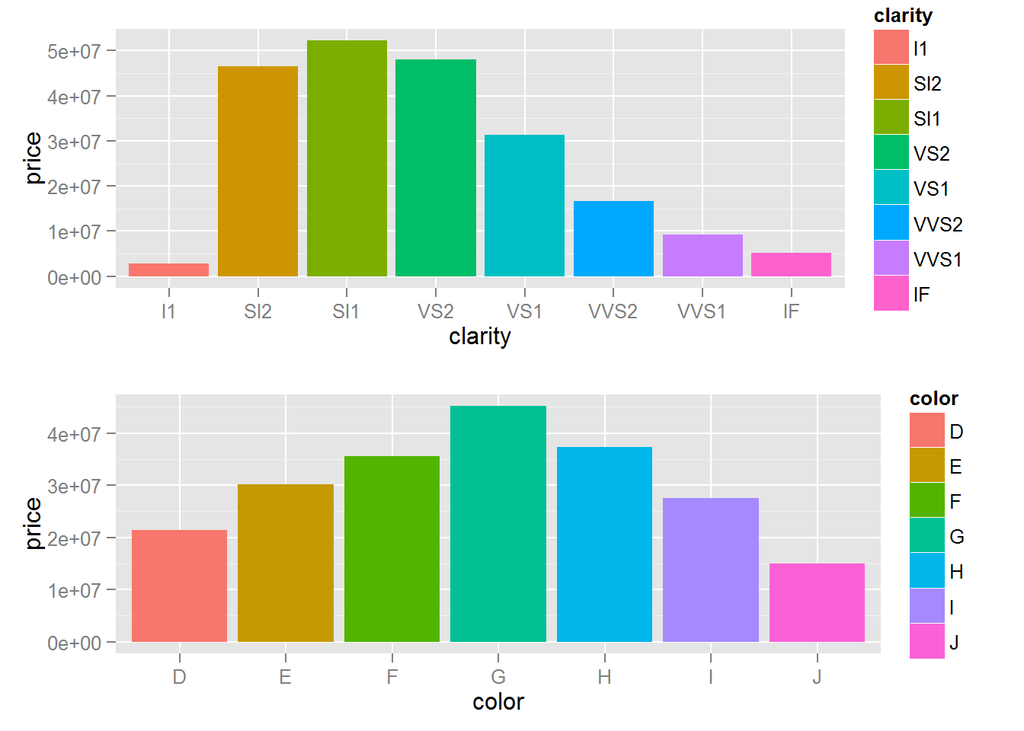

```r
#create data sets
diamonds_by_clarity <- group_by(diamonds, clarity)
diamonds_mp_by_clarity <- summarise(diamonds_by_clarity, mean_price = mean(price))

diamonds_by_color <- group_by(diamonds, color)
diamonds_mp_by_color <- summarise(diamonds_by_color, mean_price = mean(price))

#create plots
p1 = ggplot(aes(x = clarity, y = price), data = diamonds) +
  geom_bar(stat = 'identity', aes(fill = clarity))

p2 = ggplot(aes(x = color, y = price), data = diamonds) +
  geom_bar(stat = 'identity', aes(fill = color))

grid.arrange(p1,p2,ncol = 1)
```

###Observations### There does not appear to be a strong linear correlation between color or clarity and price. This leads me to believe there are multiple factors which determine price. The title of the next set of lessons is a strong indicator of this as well :).

**from course answer**

Mean price tends to decrease as clarity improves. The same can be said for color.

We encourage you to look into the mean price across cut.

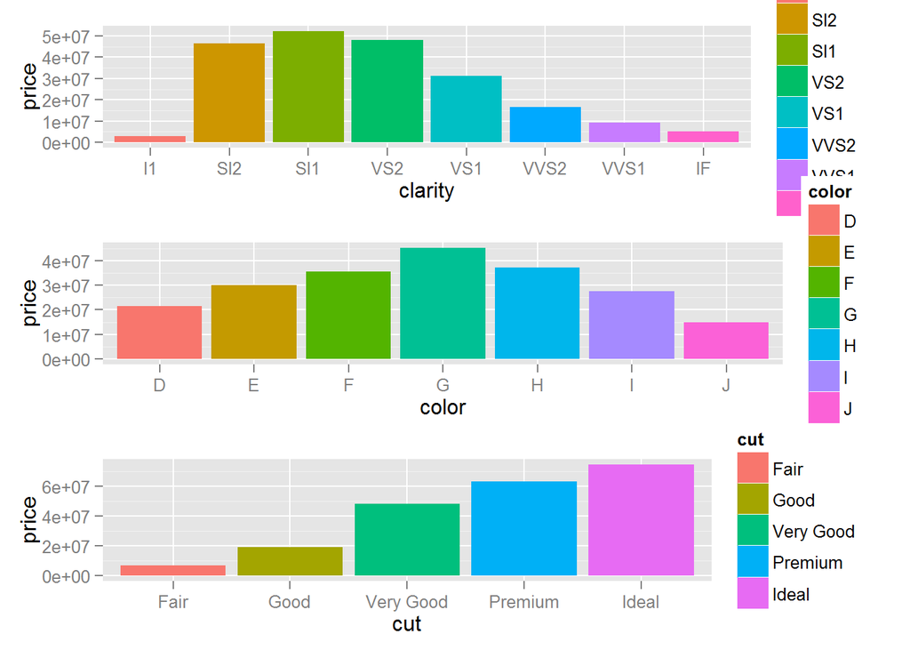

```r
diamonds_by_cut <- group_by(diamonds, cut)
diamonds_mp_by_cut <- summarise(diamonds_by_cut, mean_price = mean(price))

p3 = ggplot(aes(x = cut, y = price), data = diamonds) +
  geom_bar(stat = 'identity', aes(fill = cut))

grid.arrange(p1,p2,p3,ncol = 1)
```

The relationship between price and cut seems to be linearly correlated.

## Gapminder revisited

In your investigation, examine pairs of variable and create 2-5 plots that make use of the techniques from Lesson 4.

```r
#load the data set

 workhours <- read.csv("~/Udacity/dataAnalysisR/EDA_R_Udacity/lesson3/workinghours.csv")
names(workhours)
```

```
## [1] "X"       "country" "year"    "value"
```

### Analyze the data set

- Start with scatterplot of working hours vs. country and working hours vs. year
- Merge with HPI data set (happiness index for 135 countries)
- Determine if there is a correlation between workhours and happiness

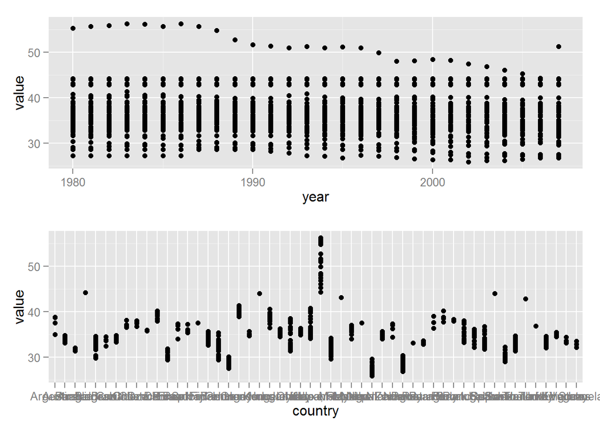

```r
gmp1 = ggplot(aes( x = year, y = value), data = workhours) +
  geom_point(fill = 'orange')

gmp2 = ggplot(aes( x = country, y = value), data = workhours) +
  geom_point(fill = 'red')

grid.arrange(gmp1,gmp2,ncol =1)
```

This data set is interesting, there are clearly some things to be learned from it, especially near the lower and upper bounds. To really do something with this data though, we need to add something. I’m going to merge this with another data set, which contains information such as happiness, gdp, and population by country.

I converted the HPI data set to csv for import.

### Import HPI Dataset

```r
hpi <- read.csv(file = '~/Udacity/dataAnalysisR/EDA_R_Udacity/lesson4/hpi.csv')
names(hpi) = tolower(names(hpi))
names(hpi)
```

```
##  [1] "hpi.rank"
##  [2] "country"
##  [3] "sub.region"
##  [4] "life..expectancy"
##  [5] "well.being..0.10."
##  [6] "happy.life.years"
##  [7] "footprint..gha.capita."
##  [8] "happy.planet.index"
##  [9] "population"
## [10] "gdp.capita...ppp."
## [11] "governance.rank..1...highest.gov.."
```

### Summarise the workhours data

```r
workhourssum <- workhours %>%
  group_by(country) %>%
  summarise(mean_hours = mean(value),
            median_hours = median(as.numeric(value)),#necessary due to bug in version 0.4.1  (2015-01-14)
            min_hours = min(value),
            max_hours = max(value),
            n = n()) %>%
  arrange(max_hours)

head(workhourssum)
```

```
## Source: local data frame [6 x 6]
##
##       country mean_hours median_hours min_hours max_hours  n
## 1 Netherlands   27.27106     27.27106  25.92308  29.61538 28
## 2     Germany   28.64751     28.64751  27.55192  30.11923 28
## 3      Norway   28.64032     28.87404  26.89615  30.37885 28
## 4     Denmark   30.38818     30.29135  29.43654  31.89808 28
## 5     Austria   31.69673     31.69673  31.35192  32.07308 28
## 6      Sweden   30.16022     30.06077  29.00769  32.21365 28
```

```r
tail(workhourssum)
```

```
## Source: local data frame [6 x 6]
##
##            country mean_hours median_hours min_hours max_hours  n
## 1         Thailand   42.84615     42.84615  42.84615  42.84615 28
## 2         Malaysia   43.15385     43.15385  43.15385  43.15385 28
## 3 Hong Kong, China   43.98077     43.98077  43.98077  43.98077 28
## 4        Sri Lanka   44.00000     44.00000  44.00000  44.00000 28
## 5       Bangladesh   44.25000     44.25000  44.25000  44.25000 28
## 6      Korea, Rep.   51.29188     51.20192  44.32692  56.21154 28
```

### Merge workhours and hpi

```r
merged = merge(workhourssum,hpi, by = 'country')
```

```r
write.csv(merged, '~/Udacity/dataAnalysisR/EDA_R_Udacity/lesson4/workhours_hpi.csv')
```

### Plot workhours vs.hpi rank

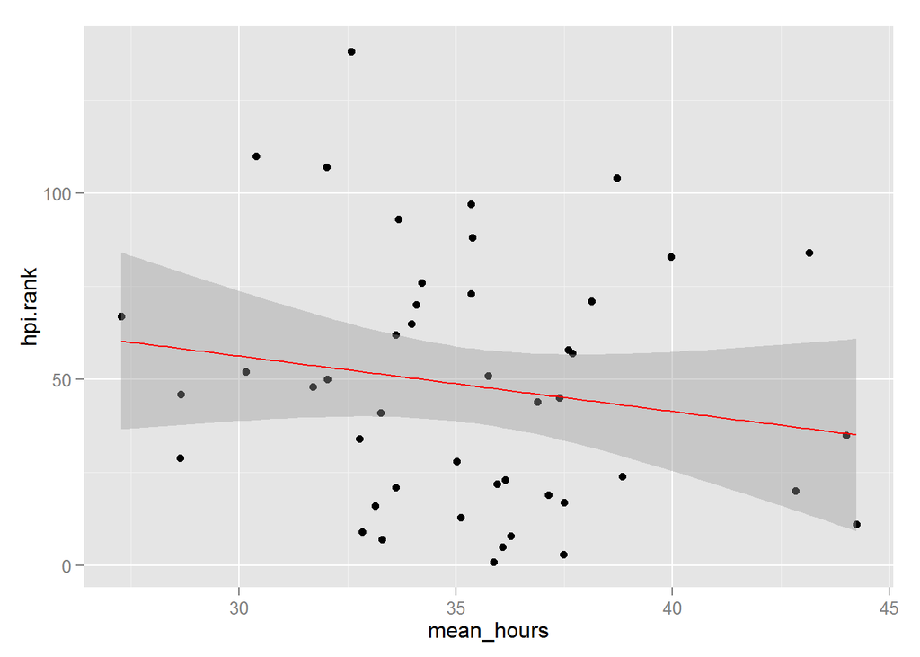

```r
ggplot(aes(x = mean_hours, y = hpi.rank), data = merged) +
  geom_point() +
  geom_smooth(method = 'lm',color = 'red')
```

No surprises here, it looks like there is a negative relationship between hours worked and hpi.rank.

```r
cor.test(merged$mean_hours, merged$hpi.rank)
```

```
##
##  Pearson's product-moment correlation
##
## data:  merged$mean_hours and merged$hpi.rank
## t = -1.1199, df = 44, p-value = 0.2689
## alternative hypothesis: true correlation is not equal to 0
## 95 percent confidence interval:
##  -0.4357107  0.1301175
## sample estimates:
##        cor
## -0.1664686
```

There is a weak negative correlation between hours worked and happiness rank. The gapminder data sest (hours worked) only contained 46 countries (merge key) with the 135 countries in the HPI data set. This analysis is in sore need for more observations.